# ndvi_maple_fire

[output not shown]

### Pinpoint location of the Maple Fire

The Maple Fire was a wildfire in the Olympic Mountains, Washington. The fire was caused by a crew of timber poachers who were attempting to steal Big-Leaf Maple trees from the Olympic National Park. The crew discovered a potential target tree on August 3, 2018, but were unable to harvest it due to a wasp nest at the base of the tree. After failing to exterminate the nest with insecticides, the crew deliberately set fire to the nest. The fire grew out of control, and the logging crew fled. The fire was reported the following day, and it was not considered contained until October 10, and continued to smolder until seasonal rains finally extinguished it in November. The Maple Fire ultimately burned 3,300 acres (13 km2) of wildland, and was the first time that tree DNA has ever been used in a federal trial in the United States.

[interactive chart not shown]

### Difference in NDVI from before and after the Maple Fire

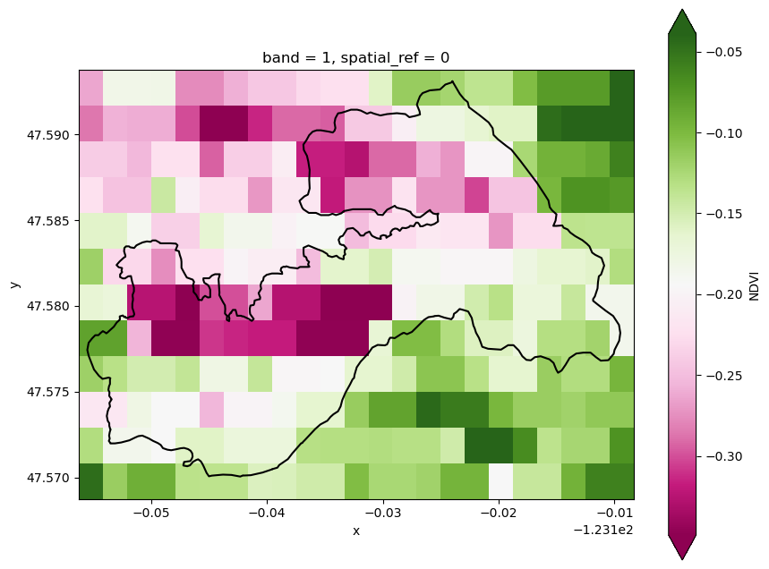